# Using DCT for Image Compression

based on https://inst.eecs.berkeley.edu/~ee123/sp16/Sections/JPEG_DCT_Demo.html

```python
# Import functions and libraries
import numpy as np
import matplotlib.pyplot as plt
import matplotlib.image as image

import numpy as np
import scipy as sc
import scipy.fft as fft

import statsmodels.tsa.stattools as stools

%matplotlib inline
plt.rcParams['figure.figsize'] = (20.0, 7.0)
```

We load an image from the file system.

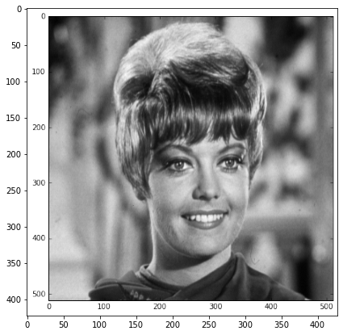

```python
im = image.imread('pic1.png')
f = plt.figure()
plt.imshow(im,cmap='gray')
```

```python
def rgb2grey(im):
    grey = im[:,:,0] + im[:,:,1] + im[:,:,2]
    return(grey)
```

We concentrate on B&W images here. The image is actually B&W, but still stored as RGB vale => we convert it into a 2D array holding grey scale values.

Since the DCT works on $8 \times 8$ pixel blocks, we shift / crop the image so that it has a size $2^N$ pixels.

```python
grey = rgb2grey(im)
grey = grey[100:356, 100:356]
```

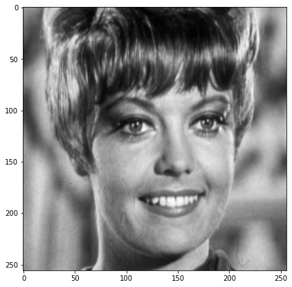

```python
f = plt.figure()
plt.imshow(grey,cmap='gray')
```

Define 2D DCT and IDCT.

```python
def dct2(a):
    return fft.dct( fft.dct( a, axis=0, norm='ortho' ), axis=1, norm='ortho' )

def idct2(a):
    return fft.idct( fft.idct( a, axis=0 , norm='ortho'), axis=1 , norm='ortho')
```

```python
imsize = grey.shape
dct = np.zeros(imsize)
```

Now we calculate the 2D DCT for $8 \times 8$ pixel blocks.

```python
for i in range(0,31):
    for j in range(0,31):
        dct[8*i:8*i+8, 8*j:8*j+8] = dct2(grey[8*i:8*i+8, 8*j:8*j+8])
dct
```

```
array([[ 1.32397060e+01,  2.96765804e-01, -4.98201624e-02, ...,
         0.00000000e+00,  0.00000000e+00,  0.00000000e+00],
       [ 5.42305708e-01, -1.37862995e-01,  4.12942618e-02, ...,
         0.00000000e+00,  0.00000000e+00,  0.00000000e+00],
       [-6.52714968e-02,  2.93762935e-03,  2.80762427e-02, ...,
         0.00000000e+00,  0.00000000e+00,  0.00000000e+00],
       ...,
       [ 0.00000000e+00,  0.00000000e+00,  0.00000000e+00, ...,
         0.00000000e+00,  0.00000000e+00,  0.00000000e+00],
       [ 0.00000000e+00,  0.00000000e+00,  0.00000000e+00, ...,
         0.00000000e+00,  0.00000000e+00,  0.00000000e+00],
       [ 0.00000000e+00,  0.00000000e+00,  0.00000000e+00, ...,
         0.00000000e+00,  0.00000000e+00,  0.00000000e+00]])
```

For fun, we can plot the DCT coefficients. We clip too high values, otherwise these dominate the picture.

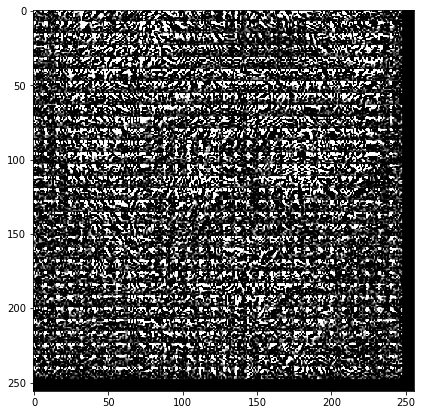

```python
f = plt.figure()
plt.imshow(dct,cmap='gray', vmax = .05, vmin = 0)
```

Now we clip the coefficients. Everything which is smaller than `thresh` is set to zero.

```python
# Threshold
thresh = 0.5
dct_thresh = dct * (abs(dct) > (thresh*np.max(dct)))
```

Calculate the block-wise IDCT.

```python
idct = np.zeros(imsize)

for i in range(0,31):
    for j in range(0,31):
        idct[8*i:8*i+8, 8*j:8*j+8] = idct2(dct_thresh[8*i:8*i+8, 8*j:8*j+8])
idct
```

```
array([[1.65496325, 1.65496325, 1.65496325, ..., 0.        , 0.        ,
        0.        ],
       [1.65496325, 1.65496325, 1.65496325, ..., 0.        , 0.        ,
        0.        ],
       [1.65496325, 1.65496325, 1.65496325, ..., 0.        , 0.        ,
        0.        ],
       ...,
       [0.        , 0.        , 0.        , ..., 0.        , 0.        ,
        0.        ],
       [0.        , 0.        , 0.        , ..., 0.        , 0.        ,
        0.        ],
       [0.        , 0.        , 0.        , ..., 0.        , 0.        ,
        0.        ]])
```

And show the corresponding image again...

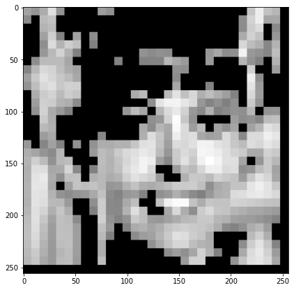

```python
f = plt.figure()
plt.imshow(idct,cmap='gray')
```

Determine the number of non-zero coefficients

```python
100*np.sum(dct_thresh != 0.0) / 256 / 256
```

```
0.933837890625
```

## Insights

Select an 8x8 block, calculate the DCT coefficients and plot a histogram.

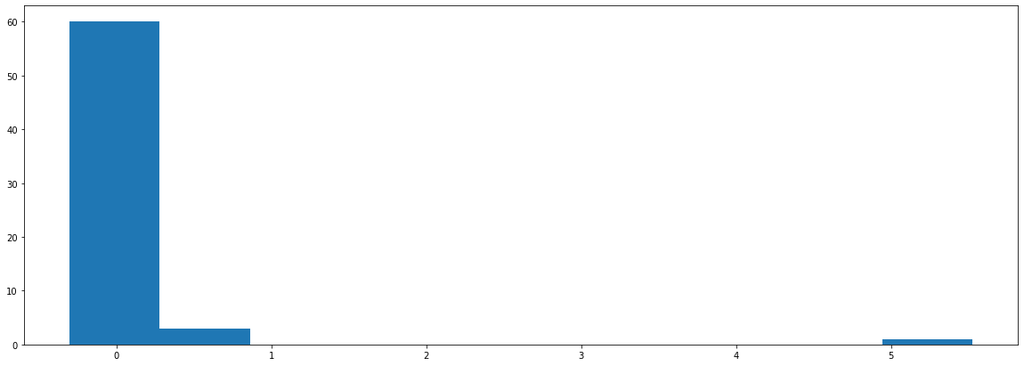

```python
i, j= 7, 20
im = grey[8*i:8*i+8, 8*j:8*j+8]
d = dct2(im)
d = d.flatten()
plt.hist(d)
```

So there many very small coefficients and only a few with large value, "compactness" property.

Let's look at correlations next.

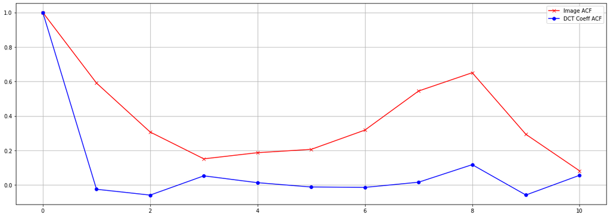

```python
acf_im = stools.acf(im.flatten(), nlags=10, fft=False)
acf_d = stools.acf(d, nlags=10, fft=False)
plt.plot(acf_im, '-rx', acf_d, '-bo')
plt.grid()
plt.legend(['Image ACF', 'DCT Coeff ACF'])
```

We can see that the image values are strongly correlated, whereas the ACF of the DCT coefficients is dropping off fairly quickly and stays around zero. So the DCT has also a decorrelation property.